# tGMM Algorithm Analysis

Eric Bridgeford

October 2, 2016

# Basis for Model

The basis for the experimental model is Expectation-Maximization of the Gaussian Mixture Model (GMM). Here, we will detail several experiments that show that our model works through data-driven simulations, demonstrate the adjustments to GMM that we make, show that they work for simulation data, and finally investigate how the experimental data fits the model.

## Basic Gaussian Mixture Model

The basic Gaussian Mixture Model hinges on Expectation-Maximization, a process for finding a locally maximizing fit for mixed distributions of the exponential family. GMM has 2 steps, the expectation (or responsibility) step, and the maximization step, and repeats until our log likelihood converges.

## Experimental Model (time-variant GMM, tGMM)

For our experiment, we have task fMRI data in which test subjects have a task presented before them at known points in time. We theorize that the latent signals driving thinking patterns can be represented by a gaussian mixture, and that we can adjust EM to predict the covariance matrices of each experimental task condition. We define our density function of an observed $x$ of some latent signal $z$:

\begin{equation} p(x_i) = \sum_{c} \pi_{ic} N(x_i | \mu_c, \Sigma_c) \end{equation}

Using our predicted covariance matrices for each experimental task condition, we can then use the Wilcoxon signed-rank test to find rois that show differential activity based on task condition.

# Model

## E Step

Like traditional GMM, our expectation step consists of computing the responsibilities of each potential cluster on our individual data points. \begin{equation} r_{ic} = \frac{\pi_{ic}N(x | \mu_c, \Sigma_c)}{\sum_{c'}\pi_{ic'}N(x | \mu_{c'}, \Sigma_{c'})} \end{equation}

where $r_ic$ represents the given responsibility of a cluster $c$ on time point $i$. This is a relatively intuitive process, as we are essentially considering the probability that a given data point is a member of a cluster and normalizing by the probability that it is in any of the clusters.

## M Step

Again, much of our process here will look very similar to traditional GMM. As we have information about how the task conditions evolve over time, however, we can skip prediction of the $\pi$ vector entirely. To define some $\rho$ vector, we can convolve a spike train $f$ of condition onsets with a response function that gives the expected proportion of signal at each successive timestep after an impulse, such that:

\begin{equation} \rho_{c} = f_c(i)*h(i) \end{equation}

For each condition $c$, and where $\rho_c$ is defined for each timestep $i$. We normalize our $\rho$ vector to sum to 1 at each time point, calling the normalized vector $\pi$:

\begin{equation} \pi_{ic} = \frac{\rho_{ic}}{\sum_c' \rho_{ic'}} \end{equation}

and now our model is simply a time-variant adaptation of GMM.

The cumulative responsibility of a given cluster $c$

\begin{equation} m_c = \sum_i r_{ic} \end{equation} For updated means. The logic behind the mean maximization is that we consider how much a particular cluster “explains” our $i$th data point, so $\mu$ is more strongly impacted by data points that it explains more effectively. \begin{equation} \hat{\mu_c} = \frac{1}{m_c} \sum_i r_{ic}x_i \end{equation} For updating the covariances. The logi here is again the same; if a point is explained well by a particular distribution, its covariance is more strongly considered than if it isn’t explained by that distribution. \begin{equation} \hat{\Sigma_c} = \frac{1}{m_c} \sum_i r_{ic}(x_i - \hat{\mu_c})^T(x_i - \hat{\mu_c}) \end{equation}

We repeat the expectation and maximization steps until we reach convergence of the likelihood (and consequently the log likelihood) of our predicted clusters matching our data.

\begin{equation} log(L) = \sum_{i=1}^N \sum_{k=1}^C \left(log(\pi_{i,k}) + log(\textcal{N}(x_{i} | \mu_k, \sigma^2)\right)) \end{equation}

## Pseudo Code

A link of the pseudo code can be found here.[tGMM](https://github.com/NeuroDataDesign/fngs/blob/gh-pages/reveal/pdfs/tGMM_algo.pdf)

## Wilcoxon Signed-Rank Test

Here, the data is clearly paired, as we would expect a relationship between correlation values taken at the within-subject level, and the within-scan level. We do not want to impose parametricity for the covariance values being analyzed, so we proceed with the non-parametric wilcoxon signed-rank test.

# Simulations

## Basic Checks

We will do a quick check of our helper methods to our algorithm to verify that we are computing probabilities correctly, and we produce the correct log probabilities, as these will be foundational for our tGMM algorithm (if they are wrong, our entire algorithm will fail).

As an easy check, we can generate some basic data, and make sure that the log likelihood for the model can be transformed to the log likelihood, given $N$ training examples for $C$ conditions, and expectation $r_{i,k}$ that our particular value is in a given cluster given our $\pi_{i,k}, \mu_k, \sigma^2$ for an example $\x_i$: \begin{equation} L = \prod_{i=1}^N \prod_{k=1}^C \left(\pi_{i, k} \textcal{N}(x_{i} | \mu_k, \sigma^2)\right)^{r_{i,k}} \end{equation}

then our log likelihood can simply be:

\begin{equation} log(L) = \sum_{i=1}^N \sum_{k=1}^C \left(log(\pi_{i,k}) + log(\textcal{N}(x_{i} | \mu_k, \sigma^2)\right)) \end{equation}

```r
require('MASS')
require('testthat')
source('./tGMM.R')
ts <- array(c(1,0,3,3,2,1.1), dim=c(6, 1))
pi_v <- array(NaN, dim=c(6,2))
pi_v[,1] <- c(.99,.99,.01,.01,.5,.99)
pi_v[,2] <- c(.01,.01,.99,.99,.5,.01)

means <- array(c(.8, 3), dim=c(1,2))
covs <- array(1, dim=c(1,1,2))

prob <- loglikelihood(ts, means, covs, pi_v)

# compute likelihood directly, and then compare its log
L <- array(NaN, dim=c(6,2))
for (i in 1:dim(ts)[1]) {
  for (c in 1:dim(pi_v)[2]) {
    L[i,c] <- pi_v[i,c]*1/(sqrt(2*pi*det(matrix(covs[,,c]))))*exp(-1/2 * ((ts[i,] - means[,c])/sqrt(covs[,,c]))^2)
  }
}

expect_equal(log(prod(L)), loglikelihood(ts, means, covs, pi_v))
```

## Simulation

```r
source('../drivers/plot_one_mtx.R')

nt <- 100
ncond <- 2
nroi <- 2
mu <- array(0, dim=c(nroi, ncond))
mu[,1] <- 3
mu[,2] <- -3
sigma <- array(NaN, dim=c(nroi, nroi, ncond))
sigma[,,1] <- diag(nroi)
sigma[,,2] <- diag(nroi)
pi_v <- array(.01, dim=c(nt, ncond))
pi_v[1:50, 1] <- .99
pi_v[51:100,2] <- .99

observed_signal <- array(0, dim=c(nt, nroi))
for (i in 1:ncond) {
  library(randomts)
  observed_signal <- pi_v[,i]*mvrnorm(n = nt, mu = mu[,i], Sigma <- sigma[,,i]) + observed_signal
}

test <- tGMM(observed_signal, pi_vec = pi_v)
trusig <- array(NaN, dim=c(nroi, nroi, ncond))
trusig[,,1] <- cov(observed_signal[1:50,])
trusig[,,2] <- cov(observed_signal[51:100,])
trumean <- array(NaN, dim=c(nroi, ncond))
trumean[,1] <- mean(observed_signal[1:50,])
trumean[,2] <- mean(observed_signal[51:100,])
```

## Exploratory

Here, we plot the timeseries as a heat map, followed by an “orthogonal projection” of this heat map, followed by the stimulus onsets.When a condition is 1, it is present; when it is 0, it is not present.

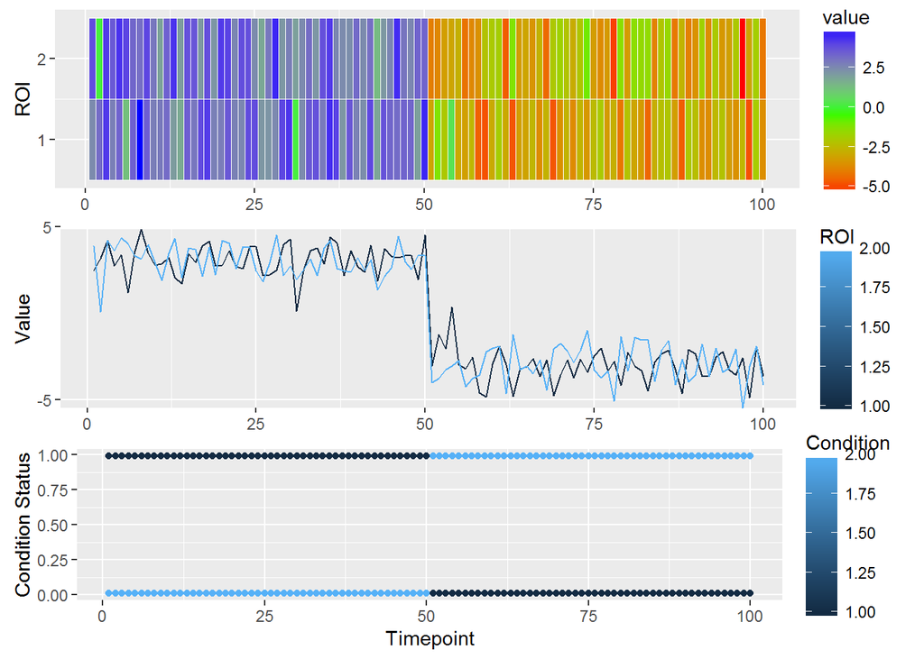

## Results

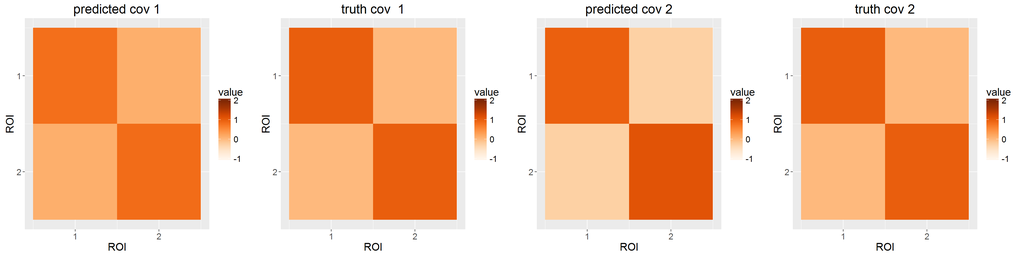

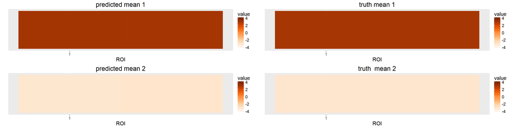

As we can see above, we do a decent job recovering the means and covariances.

# Synthetic Data

## Synthetic 1

```r
nt <- 300
nroi <- 3
nsub <- 4
nscan <- 1
ncond <- 3
covs <- array(NaN, dim=c(nroi, nroi, ncond, nsub))
means <- array(0, dim=c(nroi, ncond, nsub))

subs <- c("s1", "s2", "s1", "s2")
runs <- c("r1", "r1", "r2", "r2")
# generate sources for the random normal distributions
for (x in 1:ncond) {
  for (s in 1:nsub) {
    for (c in 1:ncond) {
      cov_sub <- diag(nroi)
      if (c == 1) {
        cov_sub[1,2] <- .75
        cov_sub[2,1] <- .75
        covs[,,c,s] <- cov_sub
        means[c,c,s] <- 1
      } else if (c == 2) {
        cov_sub[2,3] <- .75
        cov_sub[3,2] <- .75
        covs[,,c,s] <- cov_sub
        means[c,c,s] <- 1
      } else if (c == 3) {
        cov_sub[1,3] <- .75
        cov_sub[3,1] <- .75
        covs[,,c,s] <- cov_sub
        means[c,c,s] <- 1
      }
    }
  }
}
```

```r
get_pi_vector <- function(nt, nc, window, offset=4, overlap=4) {
  conditions <- array(0, dim=c(nt, nc)) # initialize empty condition vector
  for (cond in 1:nc) {
    conditions[seq((cond-1)*overlap + 1, nt, (nc-1)*overlap + offset), cond] <- 1
  }
  source('C:/Users/ebrid/Documents/GitHub/memory/code/R/drivers/convolve_trial_onsets.R')
  return(convolve_conditions(conditions, window))
}

window <- array(c(0, 1, 3, 4, 3, 3, 1, 0))
pi_v <- get_pi_vector(nt, ncond, window)
pi_v[1,] <- array(c(1,0,0))

pi_v <- pi_v/apply(pi_v, MARGIN=1, FUN=sum)
pi_v <- pi_v*.97 + .01

observed_signal <- list()
for (s in 1:(nsub*nscan)) {
  signal <- array(0, dim=c(nt, nroi))
  for (c in 1:ncond) {
    signal <- pi_v[,c]*mvrnorm(n = nt, mu = means[,c,s], Sigma <- covs[,,c,s]) + signal
  }
  observed_signal[[s]] <- signal
}
names(observed_signal) <- 1:4
```

## Exploratory Results

### Subject 1

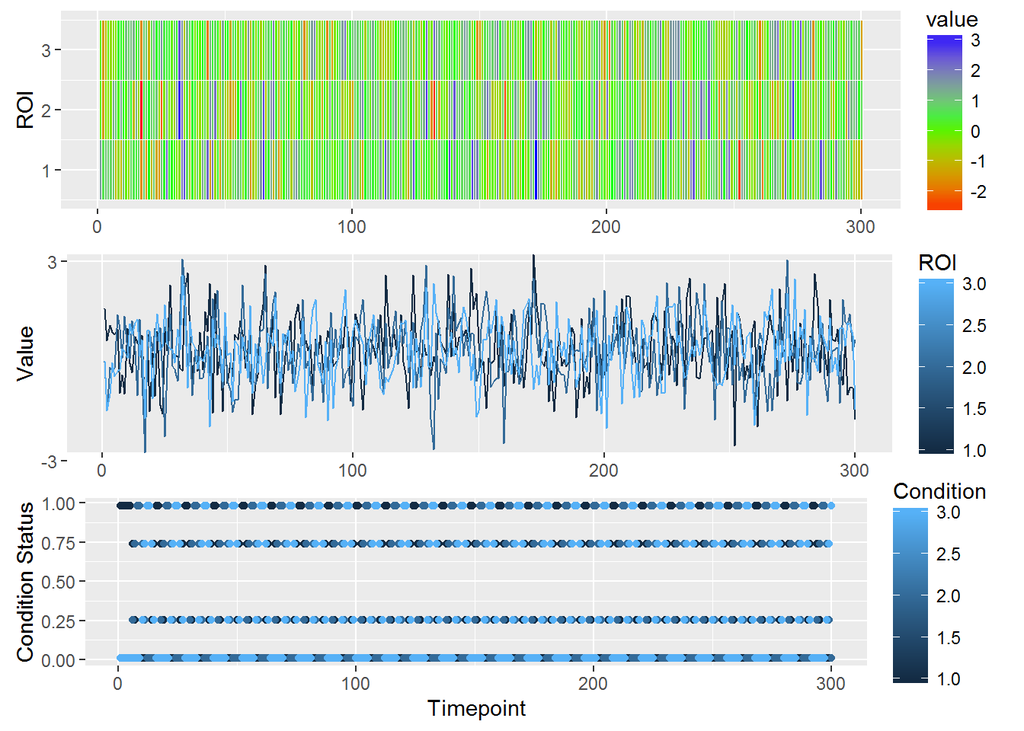

### Subject 2

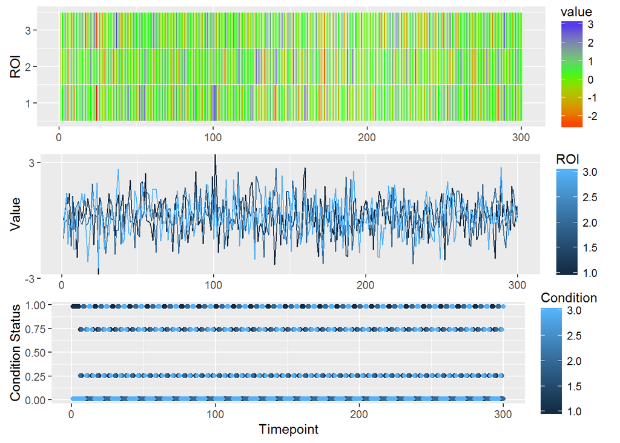

Next, we apply our algorithm to the data:

```r
tgmm_results <- sapply(observed_signal, function(ts) tGMM(ts, pi_vec = pi_v),
                              USE.NAMES=TRUE, simplify=FALSE)
cov_tgmm <- list()
mean_tgmm <- list()

cond_key <- c("c1", "c2", "c3")
for (i in 1:length(cond_key)) {
  cov_tgmm[[cond_key[i]]] <- list()
  mean_tgmm[[cond_key[i]]] <- list()

  for (id in names(tgmm_results)) {
    cov_tgmm[[cond_key[i]]][[id]] <- tgmm_results[[id]]$covs[,,i]
    mean_tgmm[[cond_key[i]]][[id]] <- tgmm_results[[id]]$means[,i]
  }
}
```

In the exploratory results below, a big thing to notice is that while we get a greater diversity of values compared to the null model. That is, note in the covariance matrices for instance. In any edges where we added a difference to our simulation model, we get a closer estimate compared to the null model. This is because of the inclusion of weights into the pi vector, instead of just using a window. However, note that since we don’t actually do any sort of maximization, our values are still yet ever so slightly regularized compared to the truths (ie, if there is supposed to be an edge for a particular condition that differs from the simple diagonal, our estimate would be slightly lower than the truth).

### Subject 1 Results

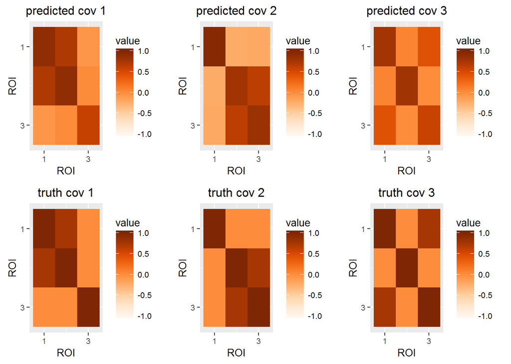

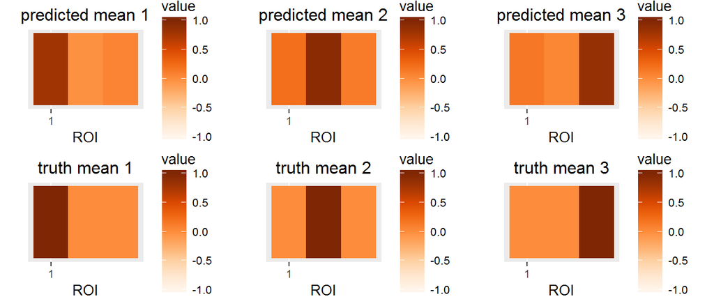

### Subject 2 Results

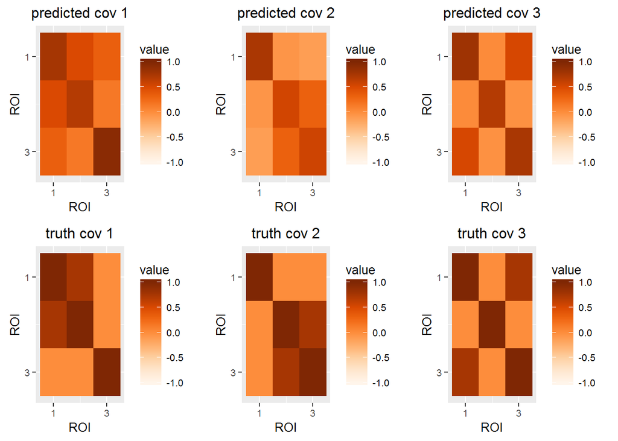

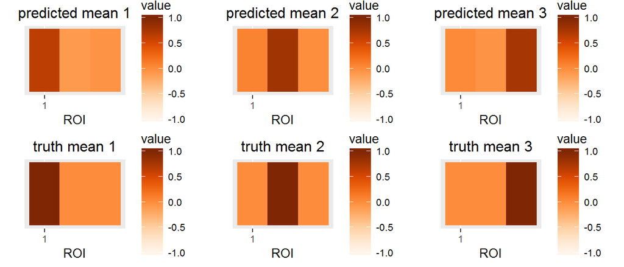

### Subject 3 Results

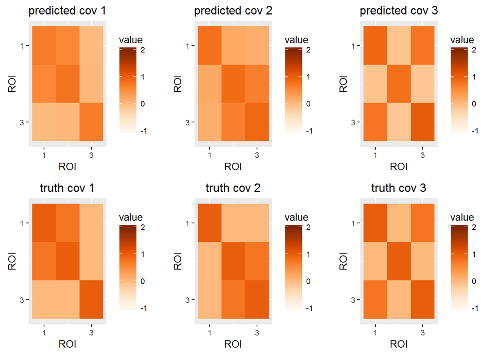

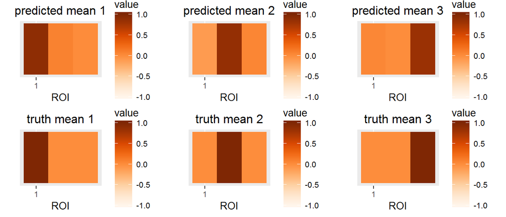

### Subject 4 Results

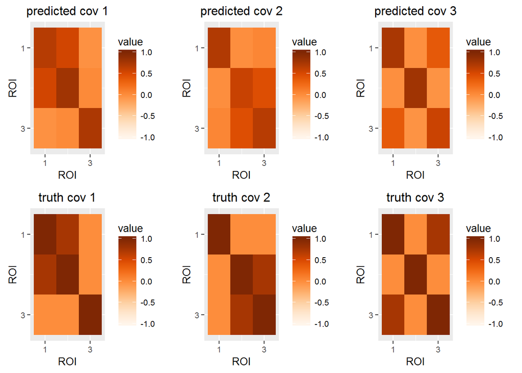

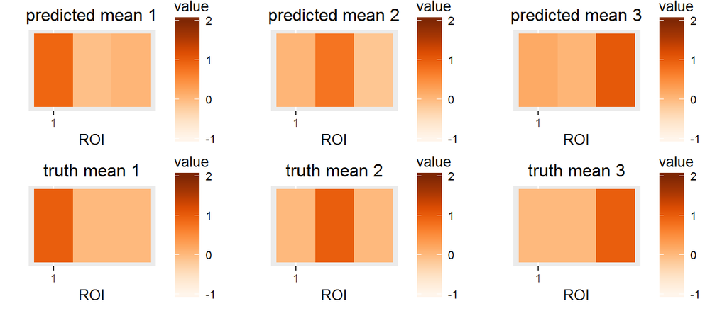

The results are a bit better than the null model.

## Wilcoxon Results

### Means

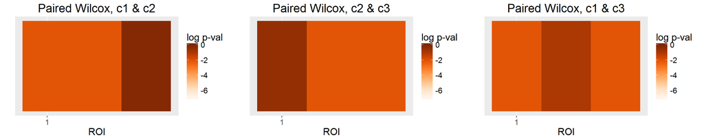

Comparing the means, we can see that, as expected, our wilcoxon test indicates an appreciable difference between ROIs 1 and 2 (since their means are quite different as we replaced ROI 1 for condition 1 and ROI 2 for condition 2). Equivalently the logic follows for condition 2 and condition 3 (we replaced ROI 2 condition 2, ROI 3 condition 3), and for condition 1 and condition 3 (we replaced ROI 1 condition 1, ROI 3 condition 3).

### Covariances

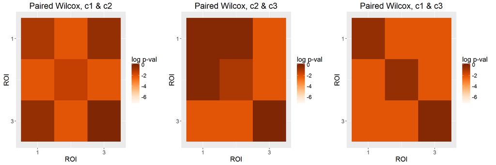

Likewise, we can see that our wilcoxon test indicates appreciable edge differences exactly where expected. Comparing the predicted covariance matrices for conditions 1 and condition 2, it is clear that the most significant edge differences are the (1,2) and (2,3) edges, replaced for condition 1 and condition 2 respectively. We note that the same pattern holds for c2 & c3 as well as c1 & c3.

## Synthetic 2

This is an idea for a more advanced simulation that will better illustrate success/failure.

Idea: use the means and covariance matrices for the overall timeseries to form a baseline for further investigation. For each condition, in the Relational/Locational wilcoxon results, choose the edges/ROIs with p values less than a threshold. Replace the edges/ROIs for the covariances/means in the relational with the maximum covariance/mean in the entire set, and replace the edges/ROIs for the covariances/means in the locational with the minimum covariance/mean in the entre set.

Here, we would expect the resulting wilcoxon test to show an appreciable difference in the particular edges that we chose to replace.

# Real Data

We get our condition onsets and store our $\pi$ vector:

```r
  ## Condition Onset/Correlation ---------------------------------------------------
  cond_key <- c("Relational", "Locational", "Incorrect")
  onsets <- get_trial_onsets(infopath, ts, subs, runs, onset_cat=c(1,1,2,2,1,1,2,2,3), cond_key=cond_key)
  onset_times <- onsets$times
  conditions <- onsets$conditions

  # Asymmetric Window
  fx <- array(rev(c(0, .1, .25, .3, .25, .2, .1, .05, .03, .02, .01)))

  pi_vecs <- sapply(onset_times, function(sub) {
    x <- abs(apply(sub, 2, function(x) as.array(convolve(x, fx, type='open')[1:length(x)])))
  }, USE.NAMES=TRUE, simplify=FALSE)
  pi_vecs <- sapply(pi_vecs, function(sub) {
     sub[,3] <- rep(.1, length=dim(sub)[1])
     sub <- sub/apply(sub, 1, sum)
     return(.97*abs(sub)+.01)
  }, USE.NAMES=TRUE, simplify=FALSE)
  cond_key <- c("Relational", "Locational", "Overall")
```

```r
  tg_results <- sapply(names(ts), function(sub) tGMM(ts[[sub]], pi_vec = pi_vecs[[sub]]),
                                USE.NAMES=TRUE, simplify=FALSE)
  tgmm_cov <- list()
  tgmm_mean <- list()

  for (i in 1:length(cond_key)) {
    tgmm_cov[[cond_key[i]]] <- list()
    tgmm_mean[[cond_key[i]]] <- list()

    for (id in names(tg_results)) {
      tgmm_cov[[cond_key[i]]][[id]] <- tg_results[[id]]$covs[,,i]
      tgmm_mean[[cond_key[i]]][[id]] <- tg_results[[id]]$means[,i]
    }
  }

  tgmm_mean_wilcox <- wilcox_test_mean(tgmm_mean, subs, runs)

  tgmm_cov_wilcox <- wilcox_test_cov(tgmm_cov, subs, runs)

  tgmm_wilcox_plot_cov <- plot_cov_wilcox(tgmm_cov_wilcox, textsize=15)

  tgmm_wilcox_plot_mean <- plot_mean_wilcox(tgmm_mean_wilcox, textsize=15)
```

## Results

### Means

#### Relational and Locational

```r
  # atlas is a oro.nifti image
  plot_brain_overlay <- function(atlas, reference, values) {
    require(RColorBrewer)
    ov <- atlas
    # sort the rois so that they go low to small, which is what pipeline outputs
    roimap <- sort(unique(array(atlas@.Data)))
    roimap <- roimap[2:length(roimap)]  # ignore 0 valued roi (no region)
    for (roi in 1:length(values)) {
      if (is.nan(values[roi])) {
        ov@.Data[round(atlas@.Data) == roi] = 0
      } else {
        ov@.Data[round(atlas@.Data) == roi] = 1-values[roi]
      }
    }
    overlay(reference, ifelse(ov >.95, ov, NA), zlim.y=c(0, 1),
            col.y=brewer.pal(n = 8, name = "Oranges"))
  }

  plot_brain_overlay(atlas, reference, tgmm_mean_wilcox$overall[[1]])
```

[output not shown]

#### Relational and Overall

```r
  plot_brain_overlay(atlas, reference, tgmm_mean_wilcox$overall[[2]])
```

[output not shown]

#### Locational and Overall

```r
  plot_brain_overlay(atlas, reference, tgmm_mean_wilcox$overall[[3]])
```

[output not shown]